# CorePAM: a PAM50-derived gene expression score with multi-cohort external validation for breast cancer prognosis and neoadjuvant pCR across RNA-seq and microarray platforms

Author

Affiliation

Rafael Botan

Published

March 1, 2026

## Abstract

**Background:** The PAM50 gene expression classifier predicts breast cancer prognosis but requires 50 genes and specialised platforms. We sought to derive CorePAM, the smallest data-driven subset of PAM50 genes that maintains non-inferior prognostic performance relative to a full 50-gene Cox elastic-net model, without pre-specifying gene count.

**Methods:** Cox elastic-net regression (alpha=0.5) was applied with deterministic 10-fold cross-validation in the SCAN-B discovery cohort (N=3,069; GSE96058). Minimum gene selection followed a pre-specified non-inferiority criterion (delta C-index = 0.010). External validation was performed in three independent cohorts: TCGA-BRCA (N=1,072; RNA-seq), METABRIC (N=1,978; Illumina microarray; endpoint: disease-specific survival), and GSE20685 (N=327; Affymetrix HGU133A). Incremental value over a clinical model (age and ER status; CORE-A) was assessed by bootstrap delta-C-index (B=1,000). Secondary analyses evaluated prediction of pathologic complete response (pCR) to neoadjuvant chemotherapy in four cohorts (N=697) plus the I-SPY2 exploratory cohort (N=986).

**Results:** CorePAM comprises **24 genes** from 50 PAM50 candidates, with an out-of-fold C-index of 0.67 (gap vs 50-gene maximum: 0.009). In validation cohorts, the CorePAM score was independently associated with survival: TCGA-BRCA (HR=1.2, p=0.016), METABRIC DSS (HR=1.41, p=3.45e-19), and GSE20685 (HR=1.4, p=0.003). Random-effects meta-analysis yielded a pooled HR of 1.35 (95% CI 1.21-1.50) (I2=44.5%, p=6.14e-08). The score provided incremental value beyond CORE-A in all cohorts. For pCR, the pooled OR was 1.69 (95% CI 1.39-2.05) (I2=0%, p=1.87e-07).

**Conclusions:** CorePAM – a 24-gene PAM50-derived score – achieves non-inferior prognostic discrimination relative to a full PAM50-gene Cox model across three independent validation cohorts spanning RNA-seq and microarray platforms, and predicts pathologic complete response to neoadjuvant chemotherapy. This reduction from 50 to 24 genes preserves prognostic performance and may facilitate implementation in resource-limited settings.

**Keywords:** breast cancer; gene expression; prognostic signature; PAM50; elastic-net regression; survival analysis; pathologic complete response; cross-platform validation

## Background

The PAM50 intrinsic subtype gene expression test classifies breast tumours into five molecular subtypes — Luminal A, Luminal B, HER2-enriched, Basal-like, and Normal-like — and underpins the Prosigna prognostic assay (Parker et al. 2009). Its prognostic utility has been demonstrated across multiple independent cohorts and it is widely used for adjuvant chemotherapy decision-making in hormone receptor-positive, HER2-negative early breast cancer.

Despite its clinical validation, PAM50 requires simultaneous measurement of all 50 genes with calibrated reference samples. Its commercial implementation (Prosigna assay) is analytically validated exclusively on the NanoString nCounter platform (Nielsen et al. 2014), with substantial per-sample costs. These requirements create barriers in settings where RNA quality is limited (e.g., formalin-fixed paraffin-embedded tissue), platforms are unavailable, or per-sample costs are prohibitive. A reduced panel measurable by targeted RT-PCR or small targeted RNA-seq assays could extend the reach of molecular stratification to resource-limited settings.

Previous attempts to reduce gene panels have typically pre-specified the target gene count before analysis, selected genes by threshold on univariate statistics, or used cohorts that mixed RNA-seq and microarray expression without platform-specific preprocessing. These approaches either introduce analytical circularity (optimising for the assumed answer) or ignore the multi-platform generalizability that clinical deployment demands.

## Methods

### Study design

This is a retrospective multicohort study exclusively using publicly available de-identified data. No new data were collected. All analytical parameters were pre-specified and frozen before any analysis (see Analytical Freeze).

### Cohorts

**Discovery cohort:** SCAN-B (GSE96058; N=3,069 primary operable breast cancers) (Brueffer et al. 2018; Saal et al. 2015) provided RNA-seq data (Illumina paired-end sequencing) with matched clinical follow-up. All 3,069 samples constitute the training cohort; the GEO metadata does not include a training/validation split column (approved decision, 2026-02-28).

**Validation cohorts (OS/DSS block):**

- *TCGA-BRCA* (N=1,072) (Cancer Genome Atlas Network 2012): RNA-seq (STAR aligner; GDC release); primary endpoint overall survival (OS).
- *METABRIC* (N=1,978; cBioPortal) (Curtis et al. 2012): Illumina HT-12 microarray; primary endpoint disease-specific survival (DSS). Deaths from other causes were censored at time of death. OS was assessed as a sensitivity analysis.
- *GSE20685* (N=327): Affymetrix HGU133A microarray; primary endpoint OS.

**pCR block cohorts (secondary analysis, independent of OS block):**

- GSE25066 (N=182) (Hatzis et al. 2011), GSE20194 (N=278) (MAQC Consortium et al. 2010), GSE32646 (N=115) (Tabchy et al. 2010), I-SPY1/GSE22226 (N=122) (Esserman et al. 2012): GEO microarray cohorts with pCR data from neoadjuvant chemotherapy trials.
- I-SPY2/GSE194040 (N=986) (Wolf et al. 2022): exploratory external cohort; pre-treatment RNA-seq biopsies; multi-arm neoadjuvant trial; batch-corrected by the original consortium using ComBat.

All cohorts underwent independent harmonisation; no expression or clinical data were pooled across cohorts.

### Analytical freeze

The following parameters were pre-specified and frozen before any analysis was performed, archived in `01_docs/registry/analysis_freeze.csv`:

| Parameter | Value |
| --- | --- |
| Non-inferiority margin (ΔC-index) | 0.010 |
| Elastic-net mixing parameter (α) | 0.5 |
| Cross-validation folds (K) | 10 |
| Minimum gene coverage (validation) | 80% |
| Time unit | months (days ÷ 30.4375) |

Gene count was explicitly *not* pre-specified; it is derived from the data.

### Expression preprocessing

All preprocessing was performed independently per cohort with no inter-cohort pooling or batch correction.

*RNA-seq cohorts (SCAN-B, TCGA-BRCA):* Raw counts were filtered with `edgeR::filterByExpr`, normalised by TMM, and transformed to log-CPM (prior.count=1). Ensembl identifiers were mapped to official HGNC symbols via `org.Hs.eg.db` (offline annotation). In the case of multiple Ensembl IDs mapping to the same HGNC symbol, the identifier with the highest intra-cohort variance was retained.

*Microarray cohorts (METABRIC, GSE20685):* Log2-scaled intensities from GEO Series Matrix files (pre-processed by the original data submitters) were used without additional normalisation. METABRIC identifiers were mapped via `org.Hs.eg.db`; GSE20685 (Affymetrix HGU133A) via `hgu133a.db`. Six PAM50 genes lack probes on HGU133A (platform ceiling: 44/50 = 88%, above the 80% minimum); of these, only two belong to the CorePAM panel (GPR160, CXXC5), giving 22/24 gene coverage (91.7%). METABRIC ER status was obtained from the cBioPortal clinical file (ER_IHC column).

*Score completeness:* When fewer than 24 CorePAM genes are available (e.g., GSE20685: 22/24 genes, 91.7%), the score is computed over available genes only, with the denominator renormalised accordingly. Gene coverage is reported per cohort; the pre-specified minimum of 80% was met in all cases. Sensitivity to missing genes is further assessed in a leave-one-gene-out analysis (Supplementary Figure S9).

### CorePAM derivation

Cox elastic-net regression (alpha=0.5 (Zou and Hastie 2005); `glmnet` package) was fitted in SCAN-B using a 10-fold cross-validation scheme. Fold assignment was *deterministic*, based on the first eight hexadecimal digits of the SHA-256 hash of each patient identifier, with event-stratification. This deterministic fold assignment ensures exact reproducibility from first principles without dependence on a random seed as driver of gene selection.

Out-of-fold (OOF) C-index was computed for each degree-of-freedom level (df = number of non-zero genes) along the regularisation path. CorePAM was defined as the *smallest df* satisfying: C_adj(df) ≥ C_adj,max − 0.010. Final model coefficients were extracted from the full-data path at the selected λ.

### Score calculation

For each cohort, the CorePAM score was computed as:

$$\text{score} = \frac{\sum_{i \in G_{\text{present}}} w_i \cdot z_i}{\sum_{i \in G_{\text{present}}} |w_i|}$$

where $z_i$ is the intra-cohort z-score of gene $i$ and $w_i$ is its weight from the frozen model, and $G_{\text{present}}$ is the set of CorePAM genes available in that cohort. The score was subsequently standardised intra-cohort (score_z = scale(score)) for proportional hazards regression, yielding hazard ratios per 1 SD. Score direction (positive = higher risk) was established in the SCAN-B training cohort (training HR = 1.92, confirming positive orientation); the same directional convention was confirmed to hold in all three external validation cohorts (all univariate HRs > 1) without requiring sign inversion in any cohort. The `score_direction` field is recorded in the analysis-ready outputs of each cohort.

### Survival analysis

**Univariate Cox:** score_z as the sole predictor; HR per 1 SD with Wald confidence intervals.

**Multivariate Cox (CORE-A model):** score_z adjusted for age (continuous) and ER status (binary), when ER was available in harmonised clinical data. CORE-A covariates by cohort: SCAN-B — age + ER status; METABRIC — age + ER status (samples with missing ER retained, ER excluded per-sample); TCGA-BRCA — age alone (ER status was not recoverable from the GDC-harmonised clinical file after standardisation: all values missing); GSE20685 — age alone (ER status absent from the GSE Series Matrix clinical annotation). The absence of ER in TCGA-BRCA and GSE20685 reflects a harmonisation limitation, not a model selection decision; the CORE-A definition was identical across cohorts (age + ER when available). CORE-A denotes the clinical-only model (age ± ER).

**C-index:** Harrell’s C-index (Harrell et al. 1982) with 95% bootstrap CI (B=1,000). During derivation, C_adj = max(C, 1−C) was used to ensure direction-invariant evaluation at the fold level; in external validation (where score direction is fixed), this equals the standard Harrell C.

**Kaplan-Meier:** dichotomised at the intra-cohort median; log-rank test. Quartile sensitivity analysis.

**Fine-Gray competing risks:** applied to METABRIC DSS (deaths from other causes as competing event).

**Incremental value:** ΔC-index = C(CORE-A + score_z) − C(CORE-A); bootstrap 95% CI (B=1,000).

**Decision curve analysis (DCA):** Net benefit at clinically relevant probability thresholds using `dcurves::dca` (OS: 60m horizon for SCAN-B/METABRIC/GSE20685; 24m for TCGA-BRCA).

**Clinical baseline model scope:** CORE-A intentionally includes only age and ER status — the two variables consistently available across all cohorts in harmonised form. TNM anatomical staging (tumour size, nodal status) was not incorporated due to insufficient cross-cohort harmonisation of staging fields in the publicly available clinical files. This constitutes a limitation acknowledged in the Discussion.

### Quality control

Comprehensive QC comprised: (i) off-diagonal score correlation between cohorts via percentile-based Spearman rho; (ii) forensic PCA of METABRIC expression for batch effects and outliers; (iii) schema/range hard-checks on all `analysis_ready` files; (iv) automated anti-hardcoding assertions verifying all reported values against source CSV/JSON files.

### Data and code availability

All raw data are publicly available (GEO, GDC, cBioPortal). Analysis code is available at https://github.com/RafaelBotan/Phd-Genomic/tree/main. All results are reproducible from the repository.

### Statistical software

R version 4.5.2. Key packages: `glmnet` (elastic-net), `survival`/`survminer` (Cox, KM), `metafor` (meta-analysis), `dcurves` (DCA), `edgeR` (RNA-seq normalisation).

## Results

### CorePAM derivation

Table 1: CorePAM derivation parameters and frozen analytical settings (Supplementary Table S1 lists all 24 selected genes and their weights).

| Parameter | Value |
| --- | --- |
| Training cohort | SCAN-B (GSE96058) |
| N (training) | 3,069 |
| Events (OS) | 322 |
| PAM50 candidates | 50 |
| Selected genes (df) | 24 |
| OOF C-index (C_adj) | 0.6699 |
| C-index gap (ΔC) | 0.0092 |
| Selected λ | 0.0079 |
| Elastic-net α | 0.5 |
| K folds | 10 |
| Non-inferiority ΔC | 0.01 |

Out-of-fold Cox elastic-net regression in SCAN-B identified 24 genes as the minimum set satisfying the pre-specified non-inferiority criterion (delta-C = 0.010). The selected model achieved an OOF C-index of 0.67, compared to the maximum OOF C-index achievable with all 50 PAM50 candidates (0.679), with a gap of 0.009 – within the 0.010 boundary. The selected 24 genes and their elastic-net Cox weights are illustrated in Figure S2 and listed in Supplementary Table S1.

The 24 genes span luminal differentiation (ESR1, PGR, NAT1), proliferation (MYBL2, PTTG1, EXO1, MYC), basal phenotype (KRT5, KRT17, FOXC1), and HER2-enriched markers (ERBB2, GRB7, MIA), with full gene list in Supplementary Table S1. The Pareto frontier (Figure S1) shows diminishing returns beyond ~15 genes, with the non-inferiority boundary crossed at df=24. Bootstrap resampling (B=200) confirmed that all 24 CorePAM genes were selected in at least 70% of resamples (Supplementary Figure S8).

Table 2: CorePAM gene coverage by validation cohort. All cohorts exceed the pre-specified 80% minimum gene coverage. Missing genes reflect platform limitations, not analytical exclusions.

[output not shown]

### Prognostic validation

Table 3: CorePAM prognostic performance across cohorts. Training cohort C-index is in-sample; OOF C-index = 0.670. CORE-A covariates by cohort: SCAN-B and METABRIC — age + ER status; TCGA-BRCA and GSE20685 — age only (ER status absent from harmonised clinical files). C-index column = standard Harrell C-index (equivalent to C_adj in validation with fixed score direction). DSS = disease-specific survival; OS = overall survival.

| Cohort | Role | Endpoint | N | Events | FU med (mo) | HR uni (95%CI) | p (uni) | C-index (95%CI) | HR adj (CORE-A) | p (CORE-A adj) |
| --- | --- | --- | --- | --- | --- | --- | --- | --- | --- | --- |
| SCANB | Training * | OS | 3069 | 322 | 55.7 | 1.92 (1.74–2.13) | 0.0000 | 0.698 (0.668–0.729) | 1.86 (1.64–2.12) | 0.0000 |
| TCGA_BRCA | Validation | OS | 1072 | 150 | 32.0 | 1.20 (1.04–1.40) | 0.0158 | 0.624 (0.572–0.678) | 1.27 (1.09–1.48) | 0.0023 |
| METABRIC | Validation | DSS | 1978 | 646 | 159.0 | 1.41 (1.31–1.52) | 0.0000 | 0.638 (0.615–0.659) | 1.36 (1.24–1.48) | 0.0000 |
| GSE20685 | Validation | OS | 327 | 83 | 112.8 | 1.40 (1.12–1.76) | 0.0034 | 0.623 (0.562–0.683) | 1.40 (1.12–1.76) | 0.0032 |

The CorePAM score was independently associated with survival in all three external validation cohorts (Table 3). In TCGA-BRCA (RNA-seq), HR per 1 SD = 1.20 (95%CI 1.04–1.40) (p=0.016). In METABRIC (DSS endpoint; Illumina microarray), HR=1.41 (95%CI 1.31–1.52) (p<0.001). In GSE20685 (Affymetrix microarray), HR=1.40 (95%CI 1.12–1.76) (p=0.003). Kaplan-Meier curves stratified at the intra-cohort median score are shown in Figure 2.

TCGA-BRCA has shorter follow-up (median 32 months), attenuating the HR; a 24-month sensitivity analysis yielded HR=1.64 (95%CI 1.24–2.16, p=0.00047; Figure S6).

Multivariate Cox regression including the CORE-A clinical model (age and ER status where available) yielded adjusted HRs of 1.27 (TCGA-BRCA), 1.36 (METABRIC), and 1.40 (GSE20685), indicating that CorePAM provides prognostic information independent of clinical covariates.

### Meta-analysis

Table 4: Random-effects meta-analysis of CorePAM prognostic association (K=3 validation cohorts). RE = random effects (REML estimator); HK = Hartung-Knapp sensitivity; OS-harm. = harmonised OS sensitivity analysis.

| Analysis | K | Pooled HR (95%CI) | p | I² (%) | τ² |
| --- | --- | --- | --- | --- | --- |
| RE univariate (primary) | 3 | 1.35 (1.21–1.50) | 6.14e-08 | 44.5 | 0.0042 |
| RE univariate (Hartung-Knapp sensitivity) | 3 | 1.35 (1.08–1.67) | 0.028 | 44.5 | 0.0042 |
| RE univariate (OS-harmonised sensitivity) | 2 | 1.27 (1.10–1.46) | 0.0009 | 16.1 | 0.0018 |

### Incremental value beyond clinical predictors

Table 5: Incremental C-index of CorePAM score over the CORE-A clinical model (age ± ER status). Bootstrap 95%CI (B=1,000, seed=42).

| Cohort | CORE-A variables | N | C (CORE-A) | C (CORE-A + Score) | ΔC-index | 95%CI |
| --- | --- | --- | --- | --- | --- | --- |
| SCANB | age+er_status | 3,069 | 0.750 | 0.780 | 0.030 | 0.014 – 0.049 |
| TCGA_BRCA | age | 1,072 | 0.638 | 0.676 | 0.038 | 0.011 – 0.086 |
| METABRIC | age+er_status | 1,978 | 0.603 | 0.646 | 0.043 | 0.025 – 0.066 |
| GSE20685 | age | 327 | 0.536 | 0.628 | 0.093 | 0.021 – 0.174 |

### Pathologic complete response (secondary analysis)

Table 6: CorePAM score predicts pCR in neoadjuvant chemotherapy cohorts. OR per 1 SD score_z. Bootstrap 95%CI (B=1,000, seed=42).

[output not shown]

In four independent neoadjuvant cohorts (N=697 total), the CorePAM score was consistently associated with higher pCR rates (Table 6). The direction of effect was positive in all four cohorts, with ORs ranging from 1.44 to 2.10 per 1 SD. The AUC ranged from 0.576 to 0.716, indicating moderate to good discriminative ability for pCR prediction.

**I-SPY2 exploratory analysis.** In the I-SPY2 external exploratory cohort (GSE194040; N=986; pCR rate=32.4%), the CorePAM score predicted pCR univariately (OR=1.68 (95%CI 1.45–1.95); AUC=0.648). Inclusion of I-SPY2 in the meta-analysis (k=5) yielded OR=1.69 (95%CI 1.50–1.90) (I²=0%), virtually identical to the primary analysis, confirming external generalizability.

## Discussion

We demonstrate that CorePAM — a 24-gene data-driven reduction of the PAM50 panel — achieves non-inferior prognostic performance relative to a full 50-gene Cox elastic-net model in three independent external cohorts spanning RNA-seq and microarray platforms. The comparator is a 50-gene Cox elastic-net model, not the commercial Prosigna/PAM50 assay (which uses centroid-based subtyping plus ROR); the non-inferiority claim is scoped to this elastic-net framework.

**Reproducible derivation.** Fold assignment was deterministic (SHA-256 of patient identifiers), eliminating random seeds as a driver of gene selection and ensuring exact reproducibility from first principles. The gene count (N=24) was not pre-specified; it was derived from the Pareto frontier of model complexity versus OOF C-index (Figure S1), where performance plateaus well before 50 genes.

**Heterogeneity is expected and informative.** The moderate I² in the OS/DSS meta-analysis reflects two structural sources: endpoint divergence (DSS in METABRIC vs. OS in the other cohorts) and differential follow-up duration (32 months in TCGA-BRCA vs. 113–159 months elsewhere). The OS-harmonised sensitivity analysis (substituting METABRIC OS for DSS) reduced I² substantially, confirming the pooled estimate is not driven by endpoint choice. The key finding is the consistency of *direction* — a positive HR in all three validation cohorts — rather than effect magnitude. The Hartung-Knapp sensitivity analysis confirmed significance under conservative inference.

**Cross-platform consistency in pCR prediction.** The pCR block showed exceptional homogeneity (I²=0% across four cohorts), consistent with the biological basis of the signal: the retained proliferation genes are directly targeted by standard neoadjuvant regimens.

**Limitations.** This is a retrospective study using public data. TCGA-BRCA has structurally short follow-up (median 32 months), attenuating the detectable HR; the 24-month sensitivity analysis (Figure S6) partially mitigates this. METABRIC uses DSS as the primary endpoint, following established precedent for that dataset. Two CorePAM genes are absent from the Affymetrix HGU133A platform used in GSE20685 (22/24 = 91.7% coverage); gene dropout sensitivity analysis confirmed minimal impact (Supplementary Figure S9). The CORE-A clinical baseline was restricted to age and ER status — the two variables consistently available across cohorts in harmonised form; TNM staging was not included due to insufficient harmonisation. ER status was unavailable in TCGA-BRCA and GSE20685, restricting CORE-A to age alone in those cohorts. The incremental value beyond a model incorporating anatomical staging should be evaluated in prospective studies. No prospective validation was performed.

## Conclusions

CorePAM is a 24-gene data-driven reduction of the PAM50 panel, derived without pre-specifying gene count, that achieves non-inferior prognostic discrimination relative to a full 50-gene Cox elastic-net model across three independent validation cohorts and two distinct expression platforms (RNA-seq and microarray). The score provides incremental value beyond a clinical baseline model, predicts pathologic complete response to neoadjuvant chemotherapy with high cross-cohort consistency (I²=0%), and generalises to the large I-SPY2 platform trial. The analytical pipeline is fully reproducible from publicly available data.

## Figures

[figure not shown]

Figure 1: Study overview. Schematic of the CorePAM derivation and validation pipeline, cohort roles, sample sizes, and frozen analytical parameters.

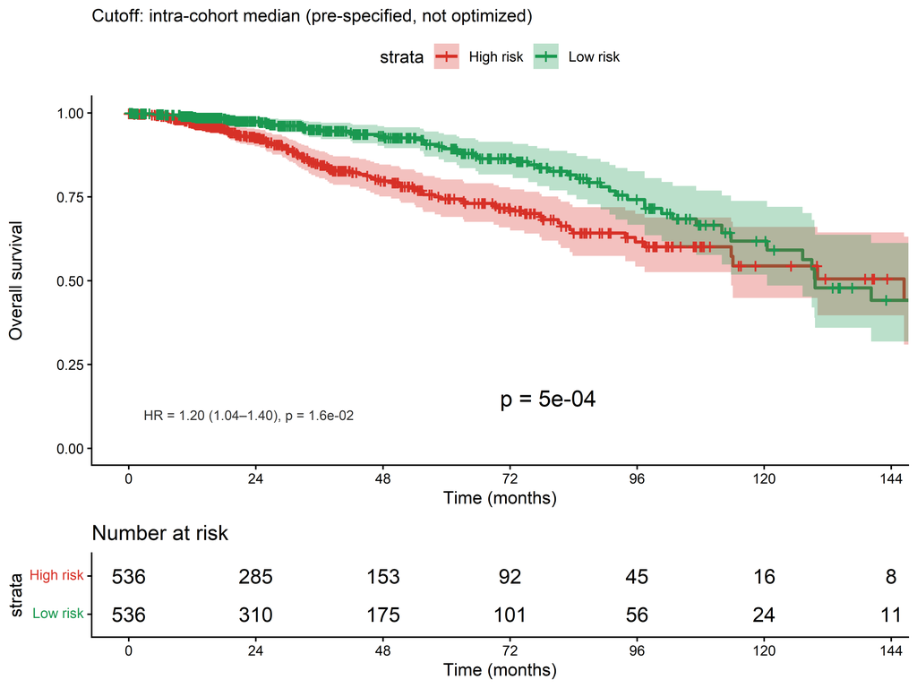

Figure 2: Kaplan-Meier survival curves in validation cohorts. Patients dichotomised at the intra-cohort median CorePAM score. Left: TCGA-BRCA (OS, N=1,072); Centre: METABRIC (DSS, N=1,978); Right: GSE20685 (OS, N=327). HR per 1 SD with 95%CI shown. Shading: 95%CI of KM estimate. Numbers at risk shown below x-axis.

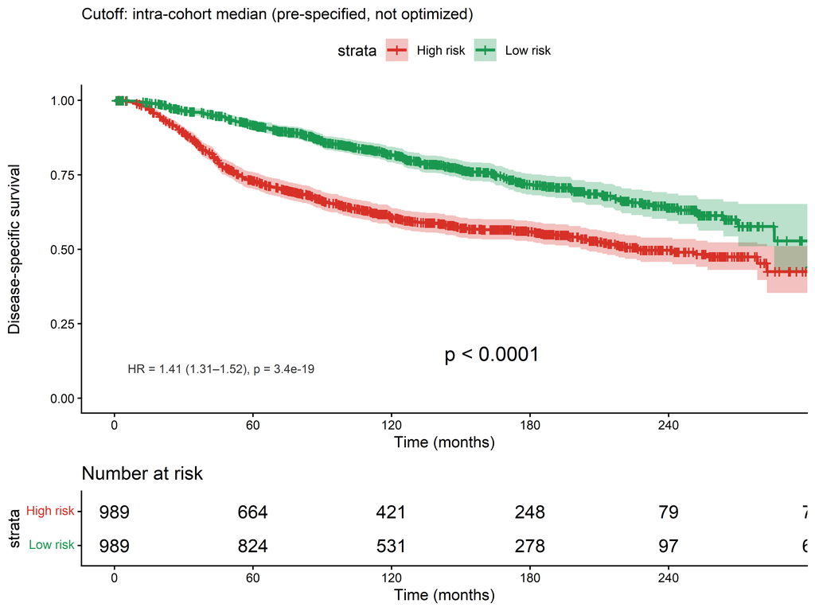

Figure 3: Kaplan-Meier survival curves in validation cohorts. Patients dichotomised at the intra-cohort median CorePAM score. Left: TCGA-BRCA (OS, N=1,072); Centre: METABRIC (DSS, N=1,978); Right: GSE20685 (OS, N=327). HR per 1 SD with 95%CI shown. Shading: 95%CI of KM estimate. Numbers at risk shown below x-axis.

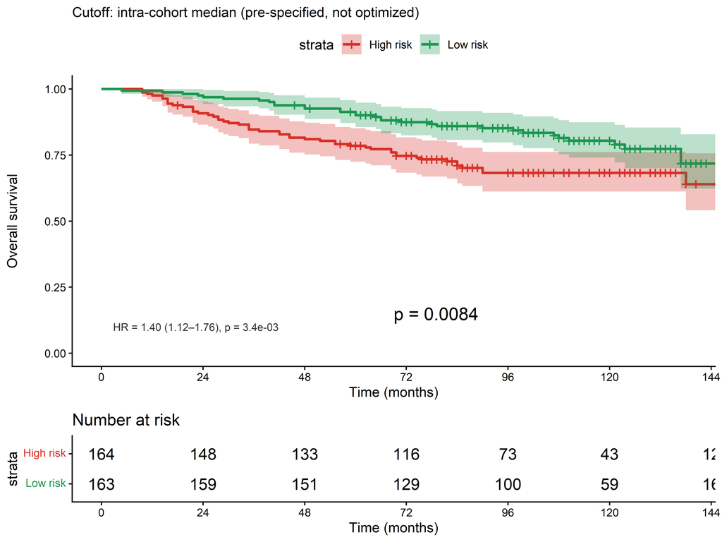

Figure 4: Kaplan-Meier survival curves in validation cohorts. Patients dichotomised at the intra-cohort median CorePAM score. Left: TCGA-BRCA (OS, N=1,072); Centre: METABRIC (DSS, N=1,978); Right: GSE20685 (OS, N=327). HR per 1 SD with 95%CI shown. Shading: 95%CI of KM estimate. Numbers at risk shown below x-axis.

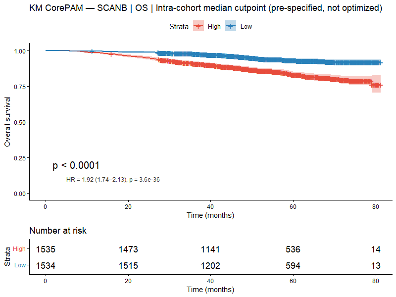

Figure 5: Kaplan-Meier survival curve in the SCAN-B training cohort. OS dichotomised at the intra-cohort median CorePAM score (N=3,069). Note: C-index in training is in-sample (0.698); out-of-fold C-index = 0.670.

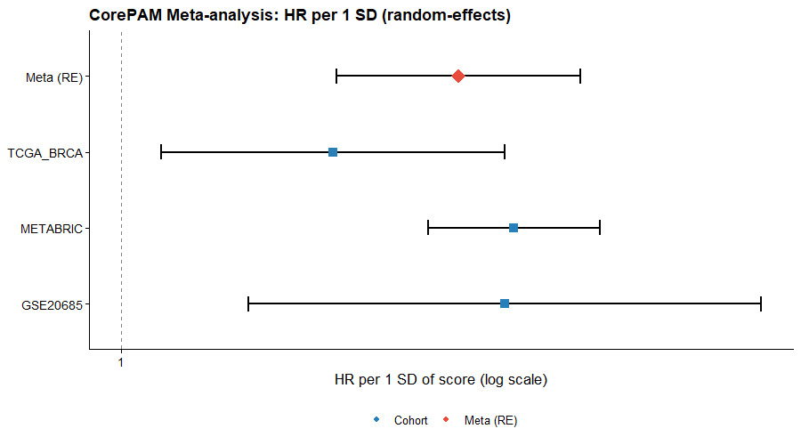

Figure 6: Forest plot — random-effects meta-analysis. HR per 1 SD CorePAM score across three validation cohorts plus pooled random-effects estimate. REML estimator.

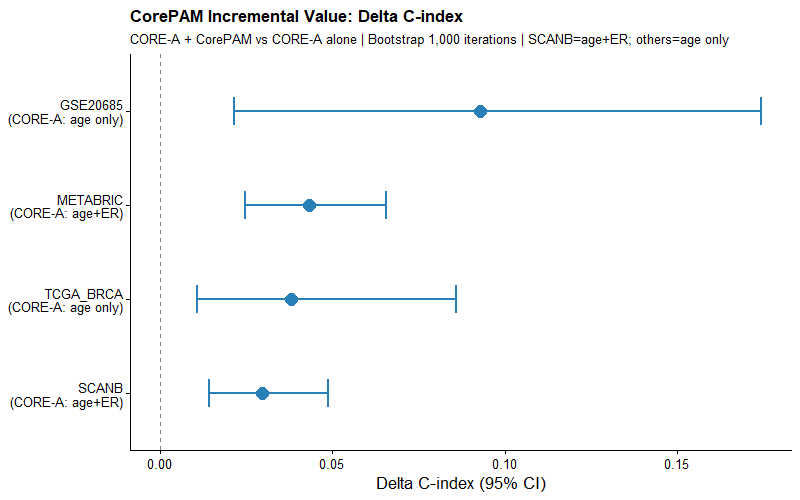

Figure 7: Incremental value and calibration. A: Delta C-index (CorePAM added to CORE-A clinical model) with 95% bootstrap CI across cohorts. B: Calibration curves at 60 months (24m for TCGA-BRCA).

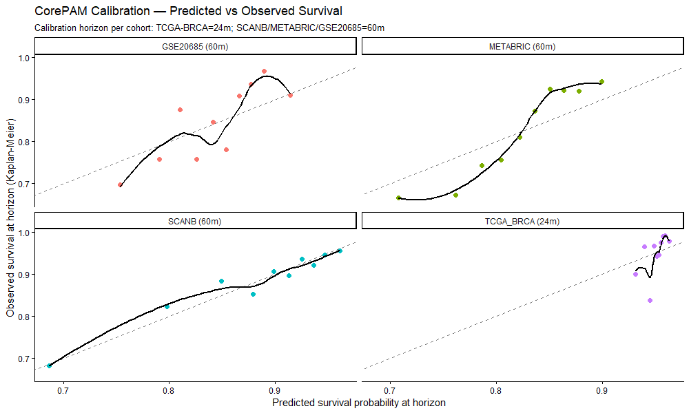

Figure 8: Incremental value and calibration. A: Delta C-index (CorePAM added to CORE-A clinical model) with 95% bootstrap CI across cohorts. B: Calibration curves at 60 months (24m for TCGA-BRCA).

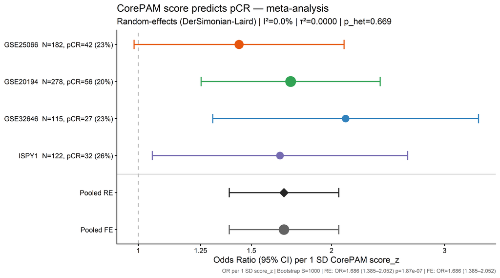

Figure 9: Forest plot — CorePAM and pCR. OR per 1 SD CorePAM score (logistic regression) in four neoadjuvant chemotherapy cohorts, with random-effects pooled estimate (DerSimonian-Laird; I²=0%).

## Supplementary Figures

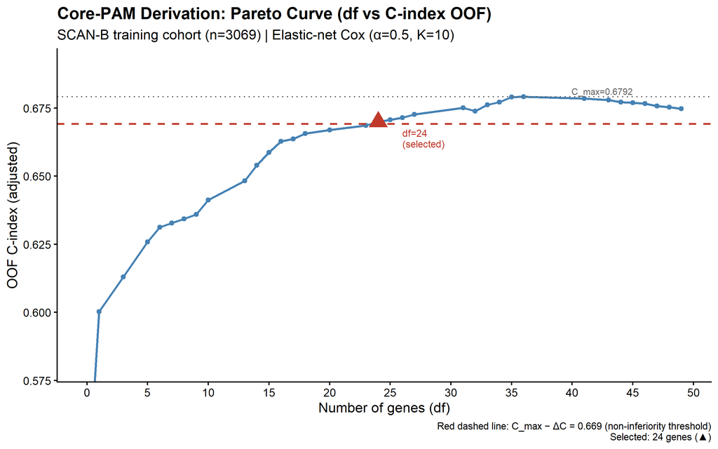

Pareto frontier: gene count vs. OOF C-index. Each point represents a unique df level (number of non-zero genes) along the glmnet regularisation path. Dashed red line: non-inferiority boundary (C_max minus 0.010). Selected CorePAM point indicated.

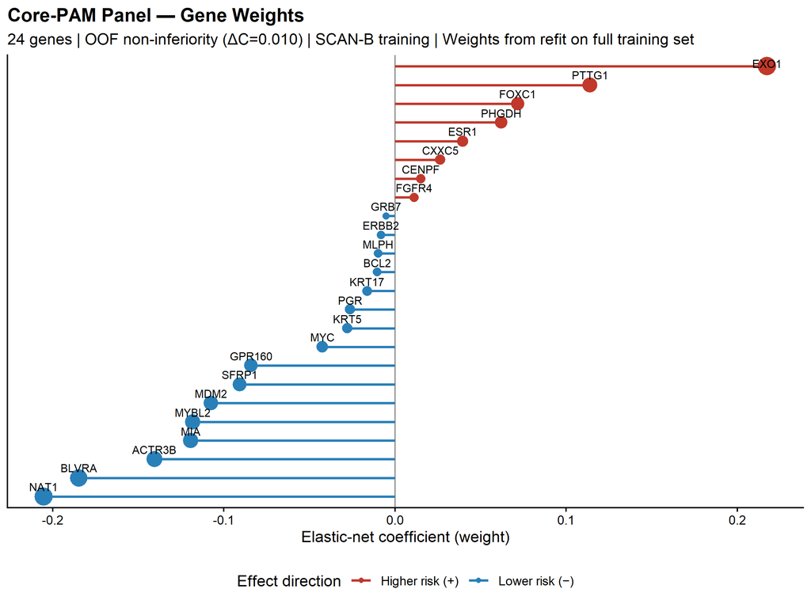

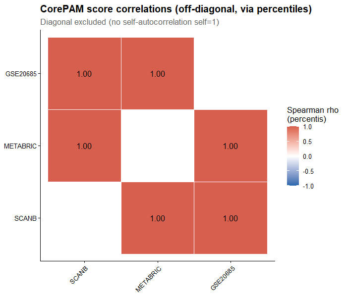

Off-diagonal CorePAM score correlations between cohorts. Spearman rho computed on paired percentiles across cohorts. Diagonal excluded (no self-autocorrelation). High correlation indicates cross-platform consistency of score distributions.

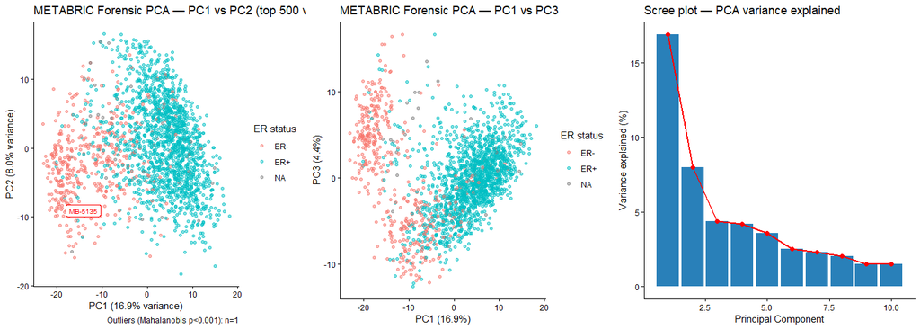

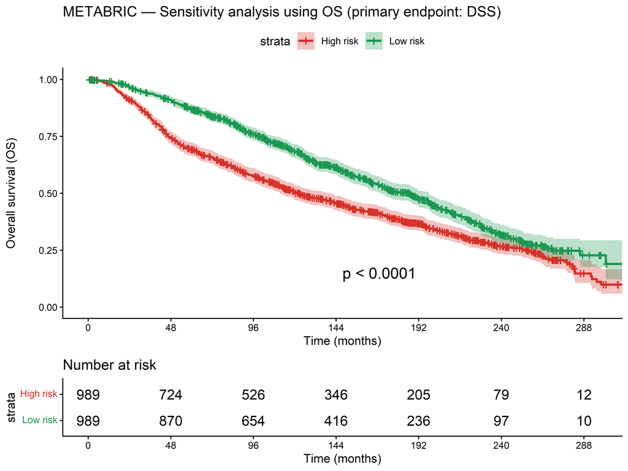

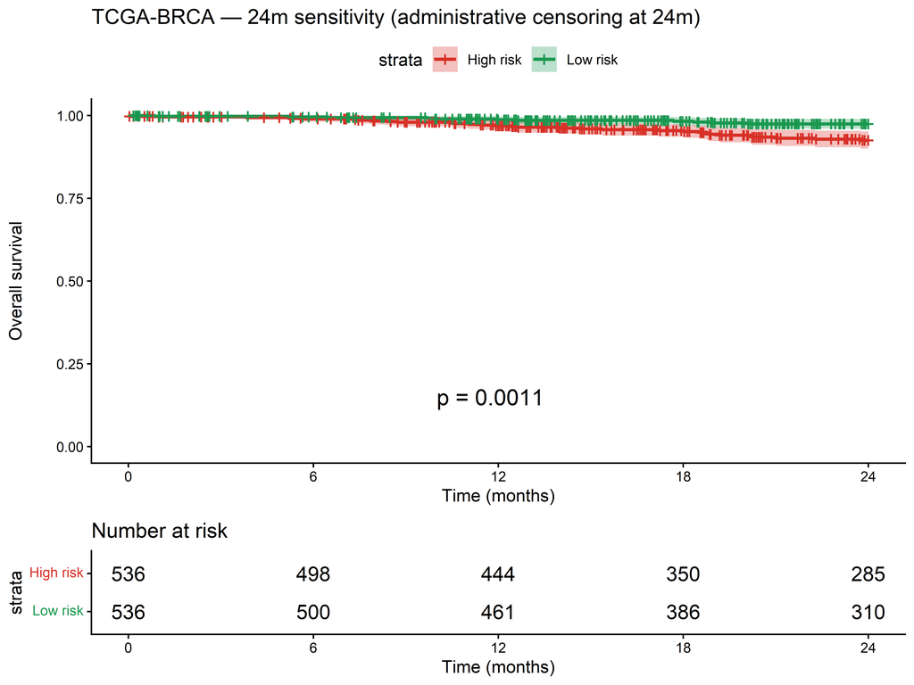

TCGA-BRCA 24-month sensitivity analysis. Patients censored at 24 months. HR=1.64 (95%CI 1.24-2.16), p=0.00047.

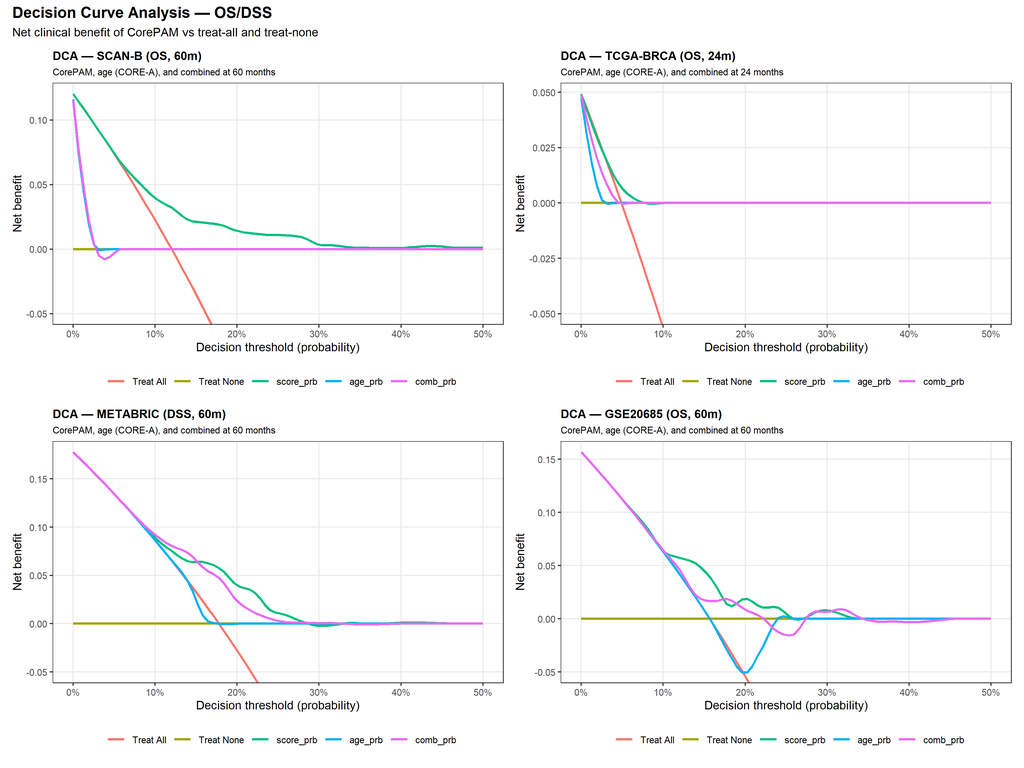

Decision curve analysis (OS). Net benefit of CorePAM score versus treat-all and treat-none strategies at clinically relevant probability thresholds. Horizons: 60 months (SCAN-B, METABRIC, GSE20685) and 24 months (TCGA-BRCA).

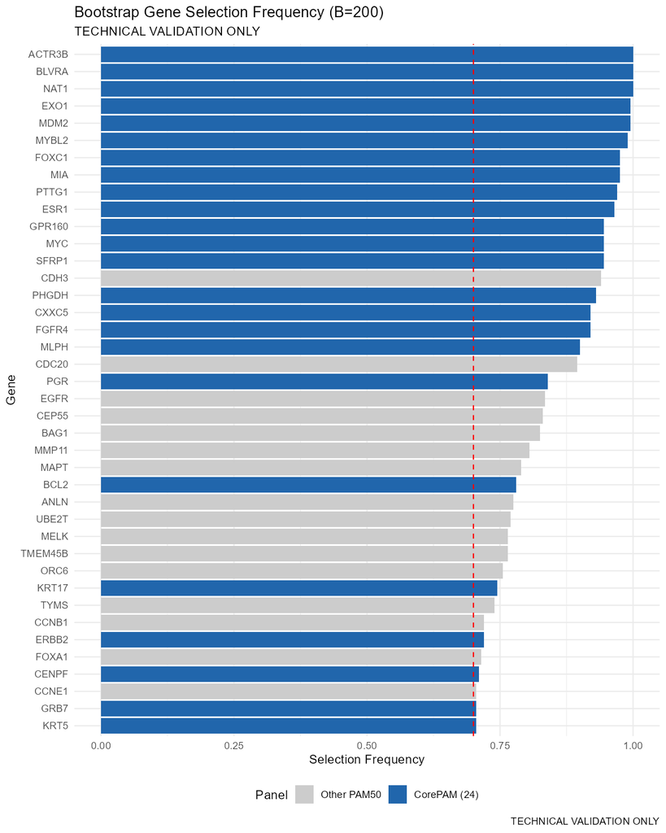

Bootstrap stability of CorePAM gene selection (B=200). Bar plot showing the frequency with which each gene was selected across 200 bootstrap refits of the Cox elastic-net model on SCAN-B training data. All 24 CorePAM genes (highlighted) were selected in at least 70% of resamples; three genes (ACTR3B, BLVRA, NAT1) were selected in 100%.

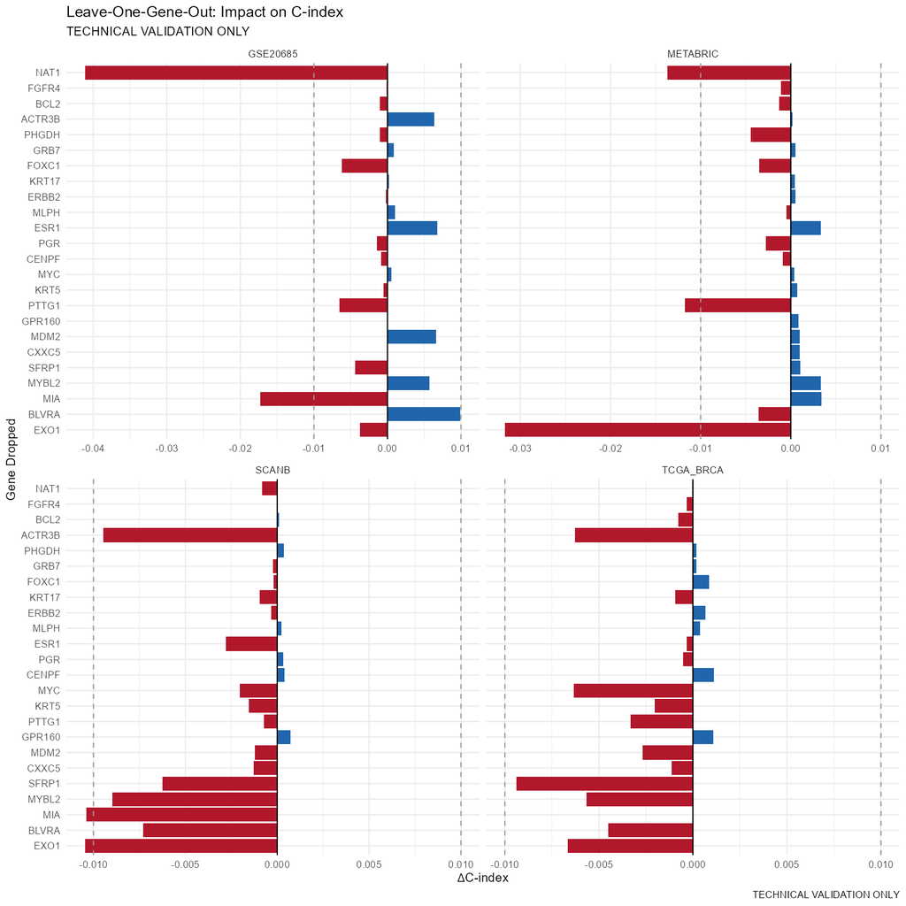

Leave-one-gene-out sensitivity analysis. Change in C-index (delta-C) when each CorePAM gene is individually removed, across all four cohorts. EXO1 and NAT1 are the most influential genes; no single gene removal causes catastrophic performance loss.

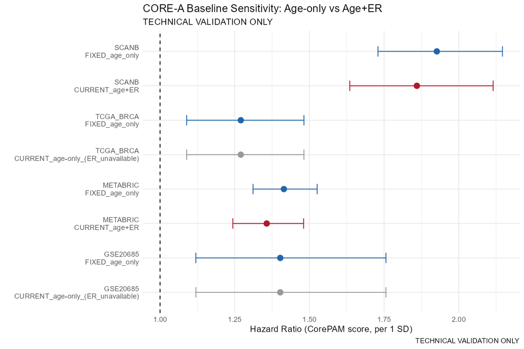

CORE-A baseline sensitivity analysis. Forest plot comparing CorePAM adjusted HR under age-only versus age+ER clinical baselines. Results are robust: maximum HR difference between baselines is 0.067 (SCAN-B); the CorePAM HR remains significant under both definitions in all cohorts.

## Declarations

**Ethics approval and consent to participate:** Not applicable. This study uses exclusively publicly available de-identified data (GEO, GDC, cBioPortal). No new human subjects research was conducted.

**Consent for publication:** Not applicable.

**Competing interests:** The author declares no competing interests.

**Funding:** No external funding was received. This study was conducted independently by the author.

**Authors’ contributions:** RB designed the study, performed all analyses, and wrote the manuscript.

**Acknowledgements:** The author thanks the SCAN-B, TCGA, METABRIC, and I-SPY consortia for making their data publicly available.

**Data availability:** All raw data are available through GEO (GSE96058, GSE25066, GSE20194, GSE32646, GSE22226, GSE194040), GDC (TCGA-BRCA), and cBioPortal (METABRIC). Analysis code and processed results are available at https://github.com/RafaelBotan/Phd-Genomic/tree/main.

## References

Brueffer, Christian, Johan Vallon-Christersson, Dorthe Grabau, Anna Ehinger, Jari Häkkinen, Cecilia Hegardt, Janne Malina, et al. 2018. “Clinical Value of RNA Sequencing–Based Classifiers for Prediction of the Five Conventional Breast Cancer Biomarkers: A Report from the Population-Based Multicenter Sweden Cancerome Analysis Network—Breast Initiative.” *JCO Precision Oncology* 2: 1–18. https://doi.org/10.1200/PO.17.00135.

Cancer Genome Atlas Network. 2012. “Comprehensive Molecular Portraits of Human Breast Tumours.” *Nature* 490 (7418): 61–70. https://doi.org/10.1038/nature11412.

Curtis, Christina, Sohrab P. Shah, Suet-Feung Chin, Gulisa Turashvili, Oscar M. Rueda, Mark J. Dunning, Doug Speed, et al. 2012. “The Genomic and Transcriptomic Architecture of 2,000 Breast Tumours Reveals Novel Subgroups.” *Nature* 486 (7403): 346–52. https://doi.org/10.1038/nature10983.

DerSimonian, Rebecca, and Nan Laird. 1986. “Meta-Analysis in Clinical Trials.” *Controlled Clinical Trials* 7 (3): 177–88. https://doi.org/10.1016/0197-2456(86)90046-2.

Esserman, Laura J., Donald A. Berry, Maggie C. U. Cheang, Christina Yau, Charles M. Perou, Lisa Carey, Angela DeMichele, et al. 2012. “Chemotherapy Response and Recurrence-Free Survival in Neoadjuvant Breast Cancer Depends on Biomarker Profiles: Results from the I-SPY 1 TRIAL (CALGB 150007/150012; ACRIN 6657).” *Breast Cancer Research and Treatment* 132 (3): 1049–62. https://doi.org/10.1007/s10549-011-1895-2.

Harrell, Frank E., Robert M. Califf, David B. Pryor, Kerry L. Lee, and Robert A. Rosati. 1982. “Evaluating the Yield of Medical Tests.” *JAMA* 247 (18): 2543–46. https://doi.org/10.1001/jama.1982.03320430047030.

Hartung, Joachim, and Guido Knapp. 2001. “On Tests of the Overall Treatment Effect in Meta-Analysis with Normally Distributed Responses.” *Statistics in Medicine* 20 (12): 1771–82. https://doi.org/10.1002/sim.791.

Hatzis, Christos, Lajos Pusztai, Vicente Valero, Daniel J. Booser, Laura Esserman, Ana Lluch, Tatiana Vidaurre, et al. 2011. “A Genomic Predictor of Response and Survival Following Taxane-Anthracycline Chemotherapy for Invasive Breast Cancer.” *JAMA* 305 (18): 1873–81. https://doi.org/10.1001/jama.2011.593.

MAQC Consortium, Leming Shi, Gregory Campbell, Wendell D. Jones, Fabien Campagne, Zhining Wen, Stephen J. Walker, et al. 2010. “The MicroArray Quality Control (MAQC)-II Study of Common Practices for the Development and Validation of Microarray-Based Predictive Models.” *Nature Biotechnology* 28 (8): 827–38. https://doi.org/10.1038/nbt.1665.

Nielsen, Torsten, Brian Wallden, Carl Schaper, Scott Ferree, Shuzhen Liu, Dongxia Gao, Garrett Barry, Naeem Dowidar, Malini Maysuria, and James Storhoff. 2014. “Analytical Validation of the PAM50-Based Prosigna Breast Cancer Prognostic Gene Signature Assay and NCPro10 Software on the NanoString nCounter Analysis System.” *The Journal of Molecular Diagnostics* 16 (4): 381–91. https://doi.org/10.1016/j.jmoldx.2014.01.009.

Parker, Joel S., Michael Mullins, Maggie C. U. Cheang, Samuel Leung, David Voduc, Tammi Vickery, Sherri Davies, et al. 2009. “Supervised Risk Predictor of Breast Cancer Based on Intrinsic Subtypes.” *Journal of Clinical Oncology* 27 (8): 1160–67. https://doi.org/10.1200/JCO.2008.18.1370.

Saal, Lao H., Johan Vallon-Christersson, Jari Häkkinen, Cecilia Hegardt, Dorthe Grabau, Christof Winter, Christian Brueffer, et al. 2015. “The Sweden Cancerome Analysis Network — Breast (SCAN-B) Initiative: A Large-Scale Multicenter Infrastructure Towards Implementation of Breast Cancer Genomic Analyses in the Clinical Routine.” *Genome Medicine* 7 (1): 20. https://doi.org/10.1186/s13073-015-0131-9.

Tabchy, Adel, Vicente Valero, Tatiana Vidaurre, Ana Lluch, Henry Gomez, Miguel Martin, Yuan Qi, et al. 2010. “Evaluation of a 30-Gene Paclitaxel, Fluorouracil, Doxorubicin, and Cyclophosphamide Chemotherapy Response Predictor in a Multicenter Randomized Trial in Breast Cancer.” *Clinical Cancer Research* 16 (21): 5351–61. https://doi.org/10.1158/1078-0432.CCR-10-1265.

Viechtbauer, Wolfgang. 2010. “Conducting Meta-Analyses in R with the metafor Package.” *Journal of Statistical Software* 36 (3): 1–48. https://doi.org/10.18637/jss.v036.i03.

Wolf, Denise M., Christina Yau, Julia Wulfkuhle, Lamorna Brown-Swigart, Rosa I. Gallagher, Po Rue Lee, Zheng Zhu, et al. 2022. “Redefining Breast Cancer Subtypes to Guide Treatment Prioritization and Maximize Response: Predictive Biomarkers Across 10 Cancer Therapies.” *Cancer Cell* 40 (6): 609–623.e6. https://doi.org/10.1016/j.ccell.2022.05.005.

Zou, Hui, and Trevor Hastie. 2005. “Regularization and Variable Selection via the Elastic Net.” *Journal of the Royal Statistical Society: Series B (Statistical Methodology)* 67 (2): 301–20. https://doi.org/10.1111/j.1467-9868.2005.00503.x.